# Instructions

- Some parts of the code are already done for you
- You need to execute all the cells
- You need to add the code where ever you see `"#### Add your code here ####"`
- Marks are mentioned along with the cells

# Face detection

Task is to predict the boundaries(mask) around the face in a given image.

## Dataset

### Mount Google drive if you are using google colab

- We recommend using Google Colab as you can face memory issues and longer runtimes while running on local

## Lib importing

```python
#Import libs
import matplotlib.pyplot as plt
import numpy as np
import cv2
from matplotlib import pyplot

from sklearn.model_selection import train_test_split

from segmentation_models import Unet
from segmentation_models import get_preprocessing
from segmentation_models.losses import bce_jaccard_loss
from segmentation_models.metrics import iou_score

from keras.applications.mobilenet import MobileNet, preprocess_input
from keras.layers import Concatenate, UpSampling2D, Conv2D, Reshape, BatchNormalization, Activation, MaxPooling2D
from keras.models import Model
from keras.preprocessing import image
from keras.layers import Dense, GlobalAveragePooling2D, Input, Dropout, Conv2DTranspose
from keras.callbacks import ModelCheckpoint
from keras import backend as T

from tensorflow.keras.losses import sparse_categorical_crossentropy
from tensorflow.keras import optimizers
from tensorflow.keras.callbacks import  EarlyStopping, ReduceLROnPlateau
from tensorflow.keras.layers import concatenate
from tensorflow.python.client import device_lib
import tensorflow as tf
```

```
Segmentation Models: using `keras` framework.
```

```python
#To see if cpu and gpu availability
print(device_lib.list_local_devices())
#only cpu
```

```
[name: "/device:CPU:0"
device_type: "CPU"
memory_limit: 268435456
locality {
}
incarnation: 2623291139381068086
]
```

```python
#Tensorflow version
tf.__version__
```

```
'1.15.0'
```

```python
#Opencv version
cv2.__version__
```

```
'3.4.4'
```

### Change current working directory to project folder (1 mark)

```python
#Set working directory
import os
os.chdir('C:/Users/sarth/Anaconda projects/great learning/AI/CNN/')
```

### Load the "images.npy" file (4 marks)

- This file contains images with details of bounding boxes

```python
#Set path from where we have to import data
DATA_PATH = 'C:/Users/sarth/Anaconda projects/great learning/AI/CNN/Project/'
data = np.load(DATA_PATH + 'images.npy',allow_pickle=True) #Loding dataset
```

```python
type(data) #Check type of data
```

```
numpy.ndarray
```

```python
data.shape  #Check shape of data
```

```
(409, 2)
```

### Check one sample from the loaded "images.npy" file (4 marks)

```python
data[0] #Understanding data
```

[output not shown]

```python
data[0][0] #here are just images
```

```
array([[[42, 37, 34],
        [56, 51, 48],
        [71, 66, 63],
        ...,
        [23, 33, 34],
        [26, 36, 37],
        [28, 38, 39]],

       [[40, 35, 32],
        [51, 46, 43],
        [64, 59, 56],
        ...,
        [27, 36, 35],
        [24, 33, 32],
        [26, 35, 34]],

       [[43, 38, 35],
        [51, 46, 43],
        [61, 56, 53],
        ...,
        [28, 30, 27],
        [33, 35, 32],
        [35, 37, 34]],

       ...,

       [[56, 47, 40],
        [57, 48, 41],
        [61, 52, 45],
        ...,
        [67, 48, 42],
        [55, 35, 28],
        [60, 40, 33]],

       [[53, 44, 37],
        [54, 45, 38],
        [57, 48, 41],
        ...,
        [59, 40, 34],
        [60, 40, 33],
        [54, 34, 27]],

       [[53, 44, 37],
        [54, 45, 38],
        [57, 48, 41],
        ...,
        [59, 40, 34],
        [70, 50, 43],
        [64, 44, 37]]], dtype=uint8)
```

```python
data[0][1] #here is the information about mask and all
```

```
[{'label': ['Face'],
  'notes': '',
  'points': [{'x': 0.08615384615384615, 'y': 0.3063063063063063},
   {'x': 0.1723076923076923, 'y': 0.45345345345345345}],
  'imageWidth': 650,
  'imageHeight': 333},
 {'label': ['Face'],
  'notes': '',
  'points': [{'x': 0.583076923076923, 'y': 0.2912912912912913},
   {'x': 0.6584615384615384, 'y': 0.46846846846846846}],
  'imageWidth': 650,
  'imageHeight': 333}]
```

```python
data[0][1][0]
```

```
{'label': ['Face'],
 'notes': '',
 'points': [{'x': 0.08615384615384615, 'y': 0.3063063063063063},
  {'x': 0.1723076923076923, 'y': 0.45345345345345345}],
 'imageWidth': 650,
 'imageHeight': 333}
```

[figure not shown]

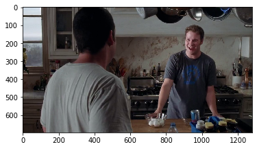

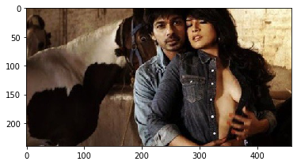

[figure not shown]

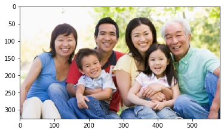

[figure not shown]

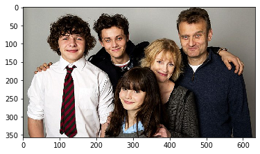

[figure not shown]

[figure not shown]

[figure not shown]

```python
#To display 10 images
for i in range(10):
    pyplot.imshow(data[i][0])
    pyplot.show()
```

### Set image dimensions (2 marks)

- Initialize image height, image width with value: 224

```python
IMAGE_WIDTH =224
IMAGE_HEIGHT =224
```

### Create features and labels

- Here feature is the image
- The label is the mask
- Images will be stored in "X_train" array
- Masks will be stored in "masks" array

```python
#Extracting mask and images seperately
masks = np.zeros((int(data.shape[0]), IMAGE_HEIGHT, IMAGE_WIDTH))
X_train = np.zeros((int(data.shape[0]), IMAGE_HEIGHT, IMAGE_WIDTH, 3))
for index in range(data.shape[0]):
    img = data[index][0]
    img = cv2.resize(img, dsize=(IMAGE_HEIGHT, IMAGE_WIDTH), interpolation=cv2.INTER_CUBIC)
    try:
        img = img[:, :, :3]
    except:
        continue
    X_train[index] = preprocess_input(np.array(img, dtype=np.float32))
    for i in data[index][1]:
        x1 = int(i["points"][0]['x'] * IMAGE_WIDTH)
        x2 = int(i["points"][1]['x'] * IMAGE_WIDTH)
        y1 = int(i["points"][0]['y'] * IMAGE_HEIGHT)
        y2 = int(i["points"][1]['y'] * IMAGE_HEIGHT)
        masks[index][y1:y2, x1:x2] = 1
```

```python
#Cross check if they are of same length or not
print(len(X_train))
print(len(masks))

#yes they are
```

```
409
409
```

### Print the shape of X_train and mask array (1 mark)

```python
X_train.shape
#Here you can see 409 images of 3 channels of size 224*224
```

```
(409, 224, 224, 3)
```

```python
masks.shape
#Here you can see 409 mask of 1 channels of size 224*224
```

```
(409, 224, 224)
```

### Print a sample image and image array

```
Clipping input data to the valid range for imshow with RGB data ([0..1] for floats or [0..255] for integers).
```

```
[[[-0.98431373 -0.98431373 -0.98431373]
  [-0.98431373 -0.98431373 -0.98431373]
  [-0.98431373 -0.98431373 -0.98431373]
  ...
  [-1.         -1.         -1.        ]
  [-1.         -1.         -1.        ]
  [-1.         -1.         -1.        ]]

 [[-0.98431373 -0.98431373 -0.98431373]
  [-0.98431373 -0.98431373 -0.98431373]
  [-0.98431373 -0.98431373 -0.98431373]
  ...
  [-1.         -1.         -1.        ]
  [-1.         -1.         -1.        ]
  [-1.         -1.         -1.        ]]

 [[-0.98431373 -0.98431373 -0.98431373]
  [-0.98431373 -0.98431373 -0.98431373]
  [-0.98431373 -0.98431373 -0.98431373]
  ...
  [-1.         -1.         -1.        ]
  [-1.         -1.         -1.        ]
  [-1.         -1.         -1.        ]]

 ...

 [[-1.         -1.         -1.        ]
  [-1.         -1.         -1.        ]
  [-1.         -1.         -1.        ]
  ...
  [-0.96862745 -0.96862745 -0.96862745]
  [-0.96078432 -0.96078432 -0.96078432]
  [-0.96078432 -0.96078432 -0.96078432]]

 [[-1.         -1.         -1.        ]
  [-1.         -1.         -1.        ]
  [-1.         -1.         -1.        ]
  ...
  [-0.96862745 -0.96862745 -0.96862745]
  [-0.96078432 -0.96078432 -0.96078432]
  [-0.95294118 -0.95294118 -0.95294118]]

 [[-1.         -1.         -1.        ]
  [-1.         -1.         -1.        ]
  [-1.         -1.         -1.        ]
  ...
  [-0.97647059 -0.97647059 -0.97647059]
  [-0.96862745 -0.96862745 -0.96862745]
  [-0.96078432 -0.96078432 -0.96078432]]]
```

[figure not shown]

```python
#see the data and visualize a image
n = 10
print(X_train[n])
pyplot.imshow(X_train[n])
```

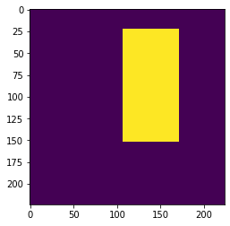

```python
#Mask of that image
pyplot.imshow(masks[n])
```

#### displaying 10 images and 10 masks

```
Clipping input data to the valid range for imshow with RGB data ([0..1] for floats or [0..255] for integers).
```

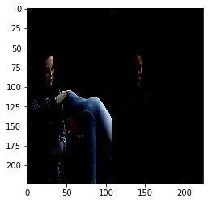

```
Clipping input data to the valid range for imshow with RGB data ([0..1] for floats or [0..255] for integers).
```

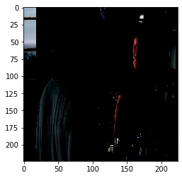

```
Clipping input data to the valid range for imshow with RGB data ([0..1] for floats or [0..255] for integers).
```

[figure not shown]

```
Clipping input data to the valid range for imshow with RGB data ([0..1] for floats or [0..255] for integers).
```

[figure not shown]

```
Clipping input data to the valid range for imshow with RGB data ([0..1] for floats or [0..255] for integers).
```

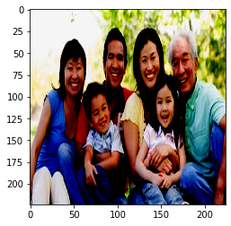

```
Clipping input data to the valid range for imshow with RGB data ([0..1] for floats or [0..255] for integers).
```

[figure not shown]

```
Clipping input data to the valid range for imshow with RGB data ([0..1] for floats or [0..255] for integers).
```

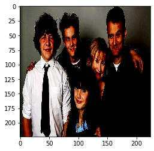

```
Clipping input data to the valid range for imshow with RGB data ([0..1] for floats or [0..255] for integers).
```

[figure not shown]

```
Clipping input data to the valid range for imshow with RGB data ([0..1] for floats or [0..255] for integers).
```

[figure not shown]

```
Clipping input data to the valid range for imshow with RGB data ([0..1] for floats or [0..255] for integers).
```

[figure not shown]

```python
for i in range(10):
    pyplot.imshow(X_train[i])
    pyplot.show()
```

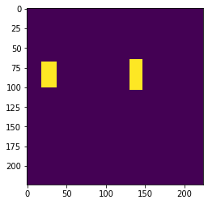

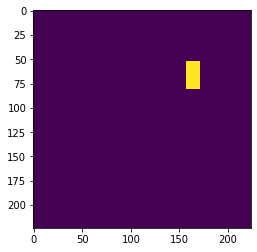

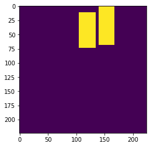

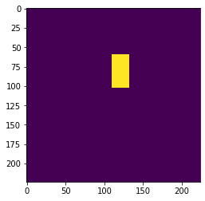

[figure not shown]

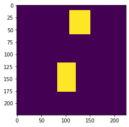

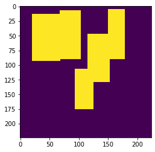

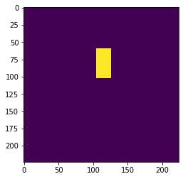

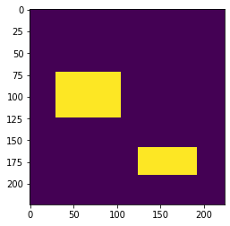

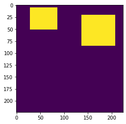

```python
for i in range(10):
    pyplot.imshow(masks[i])
    pyplot.show()
```

## Create the model (10 marks)

- Add MobileNet as model with below parameter values
  - input_shape: IMAGE_HEIGHT, IMAGE_WIDTH, 3
  - include_top: False
  - alpha: 1.0
  - weights: "imagenet"
- Add UNET architecture layers
  - This is the trickiest part of the project, you need to research and implement it correctly

```python
# SETTINGS up information
ALPHA = 1.0 # Width hyper parameter for MobileNet (0.25, 0.5, 0.75, 1.0). Higher width means more accurate but slower
IMAGE_HEIGHT = 224 #image ht
IMAGE_WIDTH = 224 #image wt
CHANNEL = 3 #channel 3
PATIENCE = 2 # Patience for early stopping
```

```python
def create_model(trainable=True):
    model = MobileNet(input_shape=(224, 224, 3), include_top=False, alpha=ALPHA,  weights='imagenet') # Load pre-trained mobilenet
    # Do not include classification (top) layer

    # to freeze layers, except the new top layer, of course, which will be added below
    for layer in model.layers:
        layer.trainable = trainable

    #Upsampling feature maps to size 224*224 so to input in unet
    block0 = model.get_layer("conv_pw_1_relu").output
    block = model.get_layer("conv_pw_1_relu").output
    block1 = model.get_layer("conv_pw_3_relu").output
    block2 = model.get_layer("conv_pw_5_relu").output
    block3 = model.get_layer("conv_pw_11_relu").output
    block4 = model.get_layer("conv_pw_13_relu").output

    x = Concatenate()([UpSampling2D()(block4), block3])
    x = Concatenate()([UpSampling2D()(x), block2])
    x = Concatenate()([UpSampling2D()(x), block1])
    x = Concatenate()([UpSampling2D()(x), block])
    x = UpSampling2D()(x)
    x = Conv2D(3, kernel_size=1, activation="relu")(x)

    #Defining unet
    base_model = Unet('mobilenet', activation='sigmoid', encoder_weights='imagenet') #unet model


    l1 = Conv2D(3, (1, 1))(x) # map N channels data to 3 channels
    out = base_model(l1)
    #l2 = Conv2D(3, (1, 1), activation='sigmoid')(out)
    l2 = Conv2D(3, (1, 1), activation='sigmoid')(out)


    return Model(inputs=model.input, outputs=l2)
```

### Call the create_model function

```python
model = create_model(False) # Arg is False, if you want to freeze lower layers for fast training (but low accuracy)
model.summary() # Print summary
```

```
WARNING:tensorflow:From C:\Users\sarth\Anaconda3\lib\site-packages\tensorflow_core\python\ops\resource_variable_ops.py:1630: calling BaseResourceVariable.__init__ (from tensorflow.python.ops.resource_variable_ops) with constraint is deprecated and will be removed in a future version.
Instructions for updating:
If using Keras pass *_constraint arguments to layers.
```

```
Model: "model_2"
__________________________________________________________________________________________________
Layer (type)                    Output Shape         Param #     Connected to
==================================================================================================
input_1 (InputLayer)            (None, 224, 224, 3)  0
__________________________________________________________________________________________________
conv1_pad (ZeroPadding2D)       (None, 225, 225, 3)  0           input_1[0][0]
__________________________________________________________________________________________________
conv1 (Conv2D)                  (None, 112, 112, 32) 864         conv1_pad[0][0]
__________________________________________________________________________________________________
conv1_bn (BatchNormalization)   (None, 112, 112, 32) 128         conv1[0][0]
__________________________________________________________________________________________________
conv1_relu (ReLU)               (None, 112, 112, 32) 0           conv1_bn[0][0]
__________________________________________________________________________________________________
conv_dw_1 (DepthwiseConv2D)     (None, 112, 112, 32) 288         conv1_relu[0][0]
__________________________________________________________________________________________________
conv_dw_1_bn (BatchNormalizatio (None, 112, 112, 32) 128         conv_dw_1[0][0]
__________________________________________________________________________________________________
conv_dw_1_relu (ReLU)           (None, 112, 112, 32) 0           conv_dw_1_bn[0][0]
__________________________________________________________________________________________________
conv_pw_1 (Conv2D)              (None, 112, 112, 64) 2048        conv_dw_1_relu[0][0]
__________________________________________________________________________________________________
conv_pw_1_bn (BatchNormalizatio (None, 112, 112, 64) 256         conv_pw_1[0][0]
__________________________________________________________________________________________________
conv_pw_1_relu (ReLU)           (None, 112, 112, 64) 0           conv_pw_1_bn[0][0]
__________________________________________________________________________________________________
conv_pad_2 (ZeroPadding2D)      (None, 113, 113, 64) 0           conv_pw_1_relu[0][0]
__________________________________________________________________________________________________
conv_dw_2 (DepthwiseConv2D)     (None, 56, 56, 64)   576         conv_pad_2[0][0]
__________________________________________________________________________________________________
conv_dw_2_bn (BatchNormalizatio (None, 56, 56, 64)   256         conv_dw_2[0][0]
__________________________________________________________________________________________________
conv_dw_2_relu (ReLU)           (None, 56, 56, 64)   0           conv_dw_2_bn[0][0]
__________________________________________________________________________________________________
conv_pw_2 (Conv2D)              (None, 56, 56, 128)  8192        conv_dw_2_relu[0][0]
__________________________________________________________________________________________________
conv_pw_2_bn (BatchNormalizatio (None, 56, 56, 128)  512         conv_pw_2[0][0]
__________________________________________________________________________________________________
conv_pw_2_relu (ReLU)           (None, 56, 56, 128)  0           conv_pw_2_bn[0][0]
__________________________________________________________________________________________________
```

[output cut: 157 more lines]

```
__________________________________________________________________________________________________
up_sampling2d_5 (UpSampling2D)  (None, 224, 224, 198 0           concatenate_4[0][0]
__________________________________________________________________________________________________
conv2d_1 (Conv2D)               (None, 224, 224, 3)  5955        up_sampling2d_5[0][0]
__________________________________________________________________________________________________
conv2d_2 (Conv2D)               (None, 224, 224, 3)  12          conv2d_1[0][0]
__________________________________________________________________________________________________
model_1 (Model)                 multiple             8336337     conv2d_2[0][0]
__________________________________________________________________________________________________
conv2d_3 (Conv2D)               (None, 224, 224, 3)  6           model_1[1][0]
==================================================================================================
Total params: 11,571,174
Trainable params: 8,318,438
Non-trainable params: 3,252,736
__________________________________________________________________________________________________
```

### Define dice coefficient function (5 marks)

- Create a function to calculate dice coefficient

```python
T.set_image_data_format('channels_last')  # TF dimension ordering
smooth = 1.

def dice_coef(y_true, y_pred):
    intersection = T.sum(y_true * y_pred, axis=[1,2,3])
    union = T.sum(y_true, axis=[1,2,3]) + T.sum(y_pred, axis=[1,2,3])
    return T.mean( (2. * intersection + smooth) / (union + smooth), axis=0)
```

### Define loss

```python
def dice_coef_loss(y_true, y_pred):
    return 1.-dice_coef(y_true, y_pred)
```

### Compile the model (5 marks)

- Complie the model using below parameters
  - loss: use the loss function defined above
  - optimizers: use Adam optimizer
  - metrics: use dice_coefficient function defined above

```python
model.compile(optimizer='adam', loss=dice_coef_loss, metrics=[dice_coef])
```